# Group Project 2

Paul Povel, Rachel Lewis, Nathan Koh, Williamn Tong, Adil Toktassyn

2024-11-07

# Introduction

In this document, we are using the Hotel Booking Cancellation Prediction dataset, a comprehensive collection of data aimed at predicting hotel booking cancellations, to try and maximize the hotel’s profit by being able to overbook the hotel. The data is originally from the article “Hotel Booking Demand Datasets”, written by Nuno Antonio, Ana Almeida, and Luis Nunes for Data in Brief, Volume 22, February 2019.

### Business Problem

The given hotel has a cancellation rate of 32.77% and therefore can not utilize it’s full capacity, thus not working at maximum profitability. Losing out on a significant amount of profit means disadvantages for the business, leading to decreased competitiveness, ultimately putting the business at risk of being unable to compete. **The question to answer is if a customer, identified by information collectable in advance, will or will not cancel their booking.**

### Business Solution

We are going to go through the process of building supervised machine learning models to facilitate the predictions.

## Step 1: Clean Data

```r
#Load Libraries
library(ggplot2)
library(dplyr)
library(corrplot)
library(caret)
#Load CSV
book = read.csv("booking.csv")

#Delete Booking_ID since it doesn't influence the prediction
book$Booking_ID = NULL

#convert date.of.reservation into dates
book$date.of.reservation <- as.Date(book$date.of.reservation, format = "%m/%d/%Y")

#remove NA values and return to date formate
book$date.of.reservation <- ifelse(is.na(book$date.of.reservation), mean(book$date.of.reservation, na.rm = TRUE), book$date.of.reservation)
book$date.of.reservation <- as.Date(book$date.of.reservation)

#extract day, day of the week, month, and year variables
book$reservation_year <- as.factor(format(book$date.of.reservation, "%Y"))
book$reservation_month <- as.factor(format(book$date.of.reservation, "%m"))
book$reservation_day <- as.factor(format(book$date.of.reservation, "%d"))
book$reservation_weekday <- as.factor(weekdays(book$date.of.reservation))
#factors due to non-linear trends

#remove date.of.reservation from dataset after extraction
book$date.of.reservation <- NULL

#remove 2015 and 2016 from dataset as there is one occurence each
book <- book %>%
  filter(reservation_year != 2015, reservation_year != 2016)

#factorize character variables
book$type.of.meal = as.factor(book$type.of.meal)
book$room.type = as.factor(book$room.type)
book$market.segment.type = as.factor(book$market.segment.type)

#make y-variable binary
book$booking.status = ifelse(book$booking.status=="Canceled",1,0)

summary(book)
```

```
##  number.of.adults number.of.children number.of.weekend.nights
##  Min.   :0.000    Min.   : 0.0000    Min.   :0.0000
##  1st Qu.:2.000    1st Qu.: 0.0000    1st Qu.:0.0000
##  Median :2.000    Median : 0.0000    Median :1.0000
##  Mean   :1.845    Mean   : 0.1053    Mean   :0.8107
##  3rd Qu.:2.000    3rd Qu.: 0.0000    3rd Qu.:2.0000
##  Max.   :4.000    Max.   :10.0000    Max.   :7.0000
##
##  number.of.week.nights       type.of.meal   car.parking.space
##  Min.   : 0.000        Meal Plan 1 :27841   Min.   :0.00000
##  1st Qu.: 1.000        Meal Plan 2 : 3305   1st Qu.:0.00000
##  Median : 2.000        Meal Plan 3 :    5   Median :0.00000
##  Mean   : 2.205        Not Selected: 5132   Mean   :0.03098
##  3rd Qu.: 3.000                             3rd Qu.:0.00000
##  Max.   :17.000                             Max.   :1.00000
##
##        room.type       lead.time         market.segment.type    repeated
##  Room_Type 1:28136   Min.   :  0.00   Aviation     :  125    Min.   :0.00000
##  Room_Type 2:  692   1st Qu.: 17.00   Complementary:  391    1st Qu.:0.00000
##  Room_Type 3:    7   Median : 57.00   Corporate    : 2017    Median :0.00000
##  Room_Type 4: 6059   Mean   : 85.23   Offline      :10529    Mean   :0.02563
##  Room_Type 5:  265   3rd Qu.:126.00   Online       :23221    3rd Qu.:0.00000
##  Room_Type 6:  966   Max.   :443.00                          Max.   :1.00000
##  Room_Type 7:  158
##       P.C              P.not.C        average.price    special.requests
##  Min.   : 0.00000   Min.   : 0.0000   Min.   :  0.00   Min.   :0.0000
##  1st Qu.: 0.00000   1st Qu.: 0.0000   1st Qu.: 80.30   1st Qu.:0.0000
##  Median : 0.00000   Median : 0.0000   Median : 99.45   Median :0.0000
##  Mean   : 0.02334   Mean   : 0.1534   Mean   :103.42   Mean   :0.6197
##  3rd Qu.: 0.00000   3rd Qu.: 0.0000   3rd Qu.:120.00   3rd Qu.:1.0000
##  Max.   :13.00000   Max.   :58.0000   Max.   :540.00   Max.   :5.0000
##
##  booking.status   reservation_year reservation_month reservation_day
##  Min.   :0.0000   2015:    0       10     : 5319     13     : 1358
##  1st Qu.:0.0000   2016:    0       09     : 4611     17     : 1345
##  Median :0.0000   2017: 6516       08     : 3813     02     : 1331
##  Mean   :0.3276   2018:29767       06     : 3203     04     : 1327
##  3rd Qu.:1.0000                    12     : 3022     19     : 1327
##  Max.   :1.0000                    11     : 2981     16     : 1306
##                                    (Other):13334     (Other):28289
##  reservation_weekday
##  Friday   :4742
##  Monday   :5380
##  Saturday :5420
##  Sunday   :6136
##  Thursday :4582
##  Tuesday  :4900
##  Wednesday:5123
```

### Step 2: Visualize the data

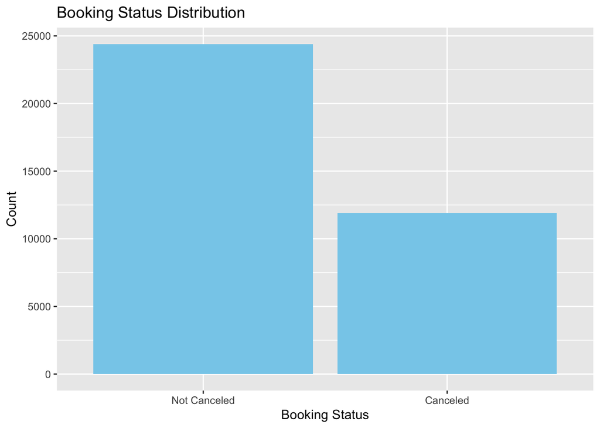

```r
# Check cancellation distribution
ggplot(book, aes(x = factor(booking.status, labels = c("Not Canceled", "Canceled")))) +
  geom_bar(fill = "skyblue") +
  labs(title = "Booking Status Distribution", x = "Booking Status", y = "Count")
```

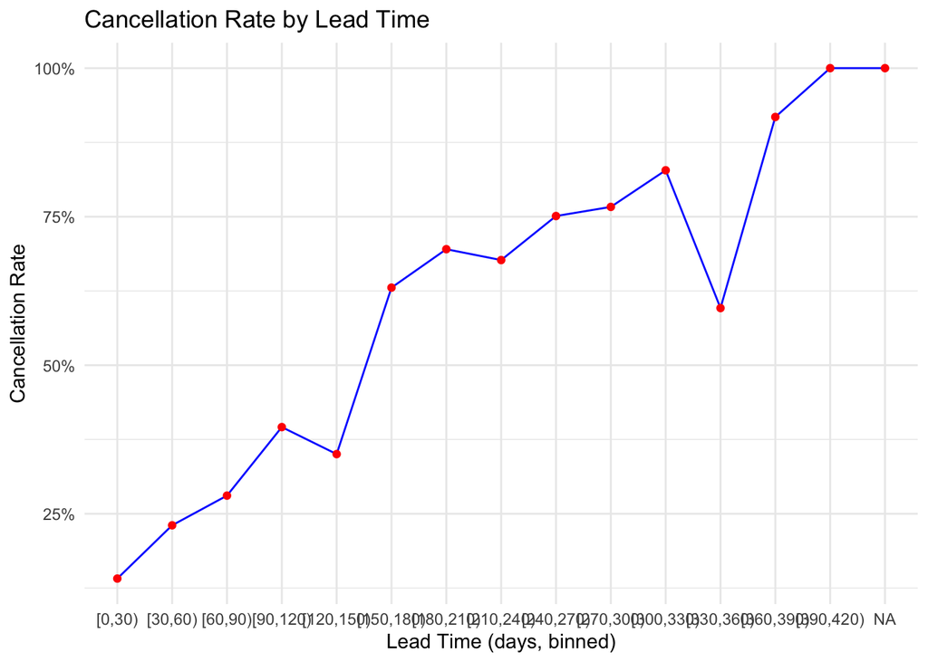

```r
# Group data by lead time intervals and calculate the cancellation rate
# Creating lead time intervals (bins) for a smoother visualization
book$lead_time_bin <- cut(book$lead.time, breaks = seq(0, max(book$lead.time, na.rm = TRUE), by = 30), right = FALSE)

# Calculate cancellation rate for each lead time bin
lead_time_cancellation <- book %>%
  group_by(lead_time_bin) %>%
  summarize(cancellation_rate = mean(booking.status), n = n())

# Plot cancellation rate by lead time bin
ggplot(lead_time_cancellation, aes(x = lead_time_bin, y = cancellation_rate)) +
  geom_line(group = 1, color = "blue") +
  geom_point(color = "red") +
  labs(title = "Cancellation Rate by Lead Time",
       x = "Lead Time (days, binned)",
       y = "Cancellation Rate") +
  theme(axis.text.x = element_text(angle = 45, hjust = 1)) +
  scale_y_continuous(labels = scales::percent) +
  theme_minimal()
```

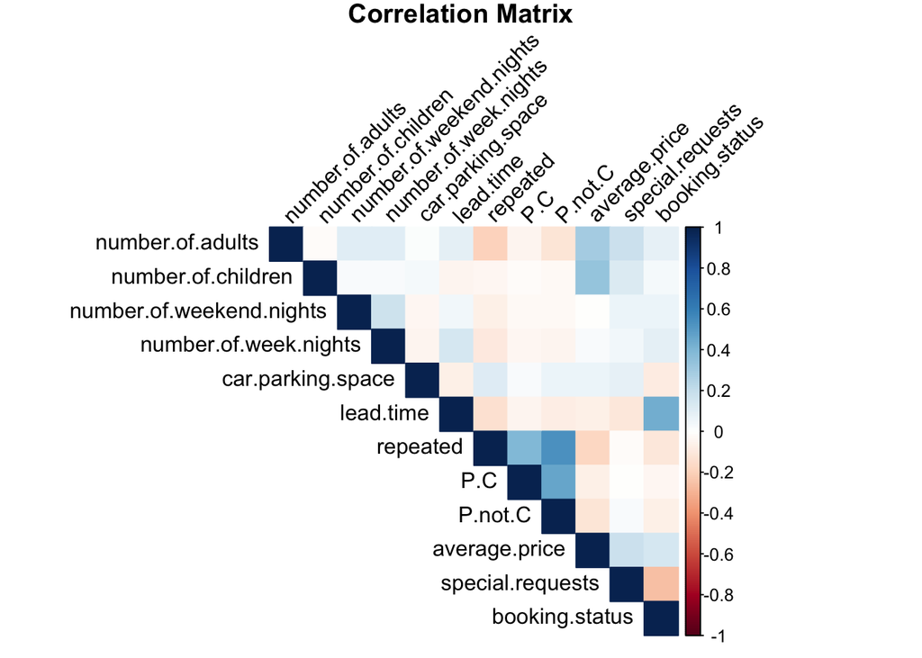

```r
# Explore correlation between numerical variables
# Remove non-numeric columns
book_numeric <- book %>% select(where(is.numeric))
# Calculate correlation matrix
corr_matrix <- cor(book_numeric, use = "complete.obs")
# Plot correlation matrix
corrplot(corr_matrix, method = "color", type = "upper", tl.col = "black", tl.srt = 45, title = "Correlation Matrix", mar = c(0, 0, 1, 0))
```

### Step 3: Split and Train the Data

```r
#70:30 split
split_size <- .7
test_size <- split_size*nrow(book)
set.seed(1234)
test_rows <- sample(1:nrow(book), test_size)

#make test and train data
book_test <- book[test_rows, ]
book_train <- book[-test_rows, ]

summary(book_train)
```

```
##  number.of.adults number.of.children number.of.weekend.nights
##  Min.   :0.000    Min.   : 0.0000    Min.   :0.000
##  1st Qu.:2.000    1st Qu.: 0.0000    1st Qu.:0.000
##  Median :2.000    Median : 0.0000    Median :1.000
##  Mean   :1.845    Mean   : 0.1048    Mean   :0.811
##  3rd Qu.:2.000    3rd Qu.: 0.0000    3rd Qu.:2.000
##  Max.   :4.000    Max.   :10.0000    Max.   :6.000
##
##  number.of.week.nights       type.of.meal  car.parking.space       room.type
##  Min.   : 0.000        Meal Plan 1 :8347   Min.   :0.0000    Room_Type 1:8362
##  1st Qu.: 1.000        Meal Plan 2 :1001   1st Qu.:0.0000    Room_Type 2: 242
##  Median : 2.000        Meal Plan 3 :   1   Median :0.0000    Room_Type 3:   4
##  Mean   : 2.215        Not Selected:1536   Mean   :0.0339    Room_Type 4:1872
##  3rd Qu.: 3.000                            3rd Qu.:0.0000    Room_Type 5:  69
##  Max.   :16.000                            Max.   :1.0000    Room_Type 6: 286
##                                                              Room_Type 7:  50
##    lead.time         market.segment.type    repeated            P.C
##  Min.   :  0.00   Aviation     :  36     Min.   :0.00000   Min.   : 0.00000
##  1st Qu.: 17.00   Complementary: 121     1st Qu.:0.00000   1st Qu.: 0.00000
##  Median : 57.00   Corporate    : 594     Median :0.00000   Median : 0.00000
##  Mean   : 84.48   Offline      :3173     Mean   :0.02499   Mean   : 0.01948
##  3rd Qu.:124.00   Online       :6961     3rd Qu.:0.00000   3rd Qu.: 0.00000
##  Max.   :443.00                          Max.   :1.00000   Max.   :13.00000
##
##     P.not.C        average.price special.requests booking.status
##  Min.   : 0.0000   Min.   :  0   Min.   :0.0000   Min.   :0.0000
##  1st Qu.: 0.0000   1st Qu.: 80   1st Qu.:0.0000   1st Qu.:0.0000
##  Median : 0.0000   Median : 99   Median :0.0000   Median :0.0000
##  Mean   : 0.1717   Mean   :103   Mean   :0.6308   Mean   :0.3252
##  3rd Qu.: 0.0000   3rd Qu.:120   3rd Qu.:1.0000   3rd Qu.:1.0000
##  Max.   :56.0000   Max.   :306   Max.   :5.0000   Max.   :1.0000
##
##  reservation_year reservation_month reservation_day reservation_weekday
##  2015:   0        10     :1606      19     : 432    Friday   :1460
##  2016:   0        09     :1353      17     : 423    Monday   :1619
##  2017:1953        08     :1129      04     : 415    Saturday :1603
##  2018:8932        06     : 974      13     : 409    Sunday   :1804
##                   12     : 908      15     : 406    Thursday :1349
##                   11     : 896      06     : 402    Tuesday  :1485
##                   (Other):4019      (Other):8398    Wednesday:1565
##    lead_time_bin
##  [0,30)   :3621
##  [30,60)  :1948
##  [60,90)  :1399
##  [90,120) :1081
##  [120,150): 679
##  (Other)  :2145
##  NA's     :  12
```

```r
summary(book_test)
```

```
##  number.of.adults number.of.children number.of.weekend.nights
##  Min.   :0.000    Min.   :0.0000     Min.   :0.0000
##  1st Qu.:2.000    1st Qu.:0.0000     1st Qu.:0.0000
##  Median :2.000    Median :0.0000     Median :1.0000
##  Mean   :1.845    Mean   :0.1056     Mean   :0.8105
##  3rd Qu.:2.000    3rd Qu.:0.0000     3rd Qu.:2.0000
##  Max.   :4.000    Max.   :9.0000     Max.   :7.0000
##
##  number.of.week.nights       type.of.meal   car.parking.space
##  Min.   : 0.0          Meal Plan 1 :19494   Min.   :0.00000
##  1st Qu.: 1.0          Meal Plan 2 : 2304   1st Qu.:0.00000
##  Median : 2.0          Meal Plan 3 :    4   Median :0.00000
##  Mean   : 2.2          Not Selected: 3596   Mean   :0.02973
##  3rd Qu.: 3.0                               3rd Qu.:0.00000
##  Max.   :17.0                               Max.   :1.00000
##
##        room.type       lead.time         market.segment.type    repeated
##  Room_Type 1:19774   Min.   :  0.00   Aviation     :   89    Min.   :0.00000
##  Room_Type 2:  450   1st Qu.: 17.00   Complementary:  270    1st Qu.:0.00000
##  Room_Type 3:    3   Median : 57.00   Corporate    : 1423    Median :0.00000
##  Room_Type 4: 4187   Mean   : 85.55   Offline      : 7356    Mean   :0.02591
##  Room_Type 5:  196   3rd Qu.:127.00   Online       :16260    3rd Qu.:0.00000
##  Room_Type 6:  680   Max.   :443.00                          Max.   :1.00000
##  Room_Type 7:  108
##       P.C            P.not.C        average.price    special.requests
##  Min.   : 0.000   Min.   : 0.0000   Min.   :  0.00   Min.   :0.000
##  1st Qu.: 0.000   1st Qu.: 0.0000   1st Qu.: 80.75   1st Qu.:0.000
##  Median : 0.000   Median : 0.0000   Median : 99.90   Median :0.000
##  Mean   : 0.025   Mean   : 0.1455   Mean   :103.59   Mean   :0.615
##  3rd Qu.: 0.000   3rd Qu.: 0.0000   3rd Qu.:120.80   3rd Qu.:1.000
##  Max.   :13.000   Max.   :58.0000   Max.   :540.00   Max.   :5.000
##
##  booking.status   reservation_year reservation_month reservation_day
##  Min.   :0.0000   2015:    0       10     :3713      13     :  949
##  1st Qu.:0.0000   2016:    0       09     :3258      16     :  935
##  Median :0.0000   2017: 4563       08     :2684      02     :  931
##  Mean   :0.3287   2018:20835       06     :2229      17     :  922
##  3rd Qu.:1.0000                    12     :2114      04     :  912
##  Max.   :1.0000                    11     :2085      19     :  895
##                                    (Other):9315      (Other):19854
##  reservation_weekday   lead_time_bin
##  Friday   :3282      [0,30)   :8533
##  Monday   :3761      [30,60)  :4433
##  Saturday :3817      [60,90)  :3200
##  Sunday   :4332      [90,120) :2438
##  Thursday :3233      [120,150):1553
##  Tuesday  :3415      (Other)  :5211
##  Wednesday:3558      NA's     :  30
```